# ML1 Assignment4-1

Yeon(Joanne), Chung

4/13/2018

```r
credit <- read.csv('./CreditBalance.csv')
# remove first column
credit$X <- NULL
head(credit)
```

```
##    Income Limit Rating Cards Age Education Gender Student Married
## 1  14.891  3606    283     2  34        11   Male      No     Yes
## 2 106.025  6645    483     3  82        15 Female     Yes     Yes
## 3 104.593  7075    514     4  71        11   Male      No      No
## 4 148.924  9504    681     3  36        11 Female      No      No
## 5  55.882  4897    357     2  68        16   Male      No     Yes
## 6  80.180  8047    569     4  77        10   Male      No      No
##   Ethnicity Balance
## 1 Caucasian     333
## 2     Asian     903
## 3     Asian     580
## 4     Asian     964
## 5 Caucasian     331
## 6 Caucasian    1151
```

```r
str(credit)
```

```
## 'data.frame':    400 obs. of  11 variables:
##  $ Income   : num  14.9 106 104.6 148.9 55.9 ...
##  $ Limit    : int  3606 6645 7075 9504 4897 8047 3388 7114 3300 6819 ...
##  $ Rating   : int  283 483 514 681 357 569 259 512 266 491 ...
##  $ Cards    : int  2 3 4 3 2 4 2 2 5 3 ...
##  $ Age      : int  34 82 71 36 68 77 37 87 66 41 ...
##  $ Education: int  11 15 11 11 16 10 12 9 13 19 ...
##  $ Gender   : Factor w/ 2 levels " Male","Female": 1 2 1 2 1 1 2 1 2 2 ...
##  $ Student  : Factor w/ 2 levels "No","Yes": 1 2 1 1 1 1 1 1 1 2 ...
##  $ Married  : Factor w/ 2 levels "No","Yes": 2 2 1 1 2 1 1 1 1 2 ...
##  $ Ethnicity: Factor w/ 3 levels "African American",..: 3 2 2 2 3 3 1 2 3 1 ...
##  $ Balance  : int  333 903 580 964 331 1151 203 872 279 1350 ...
```

```r
# Change Factor variables(Gender, Student, Married, Ethnicity) to numeric
credit$Gender <- as.numeric(credit$Gender)
credit$Student <- as.numeric(credit$Student)
credit$Married <- as.numeric(credit$Married)
credit$Ethnicity <- as.numeric(credit$Ethnicity)
head(credit)
```

```
##    Income Limit Rating Cards Age Education Gender Student Married
## 1  14.891  3606    283     2  34        11      1       1       2
## 2 106.025  6645    483     3  82        15      2       2       2
## 3 104.593  7075    514     4  71        11      1       1       1
## 4 148.924  9504    681     3  36        11      2       1       1
## 5  55.882  4897    357     2  68        16      1       1       2
## 6  80.180  8047    569     4  77        10      1       1       1
##   Ethnicity Balance
## 1         3     333
## 2         2     903
## 3         2     580
## 4         2     964
## 5         3     331
## 6         3    1151
```

```r
# Check correlation
cor(credit)
```

```
##                Income        Limit       Rating        Cards          Age
## Income     1.00000000  0.792088341  0.791377625 -0.018272610  0.175338403
## Limit      0.79208834  1.000000000  0.996879737  0.010231333  0.100887922
## Rating     0.79137763  0.996879737  1.000000000  0.053239030  0.103164996
## Cards     -0.01827261  0.010231333  0.053239030  1.000000000  0.042948288
## Age        0.17533840  0.100887922  0.103164996  0.042948288  1.000000000
## Education -0.02769198 -0.023548534 -0.030135627 -0.051084217  0.003619285
## Gender    -0.01073751  0.009396678  0.008884590 -0.022658021  0.004015496
## Student    0.01963214 -0.006015094 -0.002027646 -0.026164127 -0.029844426
## Married    0.03565236  0.031154829  0.036750773 -0.009695060 -0.073135503
## Ethnicity -0.03288753 -0.020837489 -0.020287751 -0.003866747 -0.032451326
## Balance    0.46365646  0.861697267  0.863625161  0.086456347  0.001835119
##              Education       Gender      Student     Married    Ethnicity
## Income    -0.027691982 -0.010737514  0.019632138  0.03565236 -0.032887534
## Limit     -0.023548534  0.009396678 -0.006015094  0.03115483 -0.020837489
## Rating    -0.030135627  0.008884590 -0.002027646  0.03675077 -0.020287751
## Cards     -0.051084217 -0.022658021 -0.026164127 -0.00969506 -0.003866747
## Age        0.003619285  0.004015496 -0.029844426 -0.07313550 -0.032451326
## Education  1.000000000 -0.005049071  0.072085400  0.04891059 -0.030054892
## Gender    -0.005049071  1.000000000  0.055033718  0.01245171  0.001513996
## Student    0.072085400  0.055033718  1.000000000 -0.07697370 -0.030261377
## Married    0.048910587  0.012451711 -0.076973701  1.00000000  0.060562584
## Ethnicity -0.030054892  0.001513996 -0.030261377  0.06056258  1.000000000
## Balance   -0.008061576  0.021474007  0.259017547 -0.00567349 -0.009157157
##                Balance
## Income     0.463656457
## Limit      0.861697267
## Rating     0.863625161
## Cards      0.086456347
## Age        0.001835119
## Education -0.008061576
## Gender     0.021474007
## Student    0.259017547
## Married   -0.005673490
## Ethnicity -0.009157157
## Balance    1.000000000
```

```r
# Try Ordinary Least Squares(OLS) Regreesion
credit_balance <- data.frame(scale(credit))
ols_credit <- lm(Balance~., data = credit_balance)
summary(ols_credit)
```

```
##
## Call:
## lm(formula = Balance ~ ., data = credit_balance)
##
## Residuals:
##     Min      1Q  Median      3Q     Max
## -0.3629 -0.1698 -0.0268  0.1141  0.6814
##
## Coefficients:
##               Estimate Std. Error t value Pr(>|t|)
## (Intercept)  2.991e-16  1.074e-02   0.000   1.0000
## Income      -5.978e-01  1.795e-02 -33.299  < 2e-16 ***
## Limit        9.699e-01  1.642e-01   5.908 7.58e-09 ***
## Rating       3.703e-01  1.648e-01   2.248   0.0252 *
## Cards        5.352e-02  1.293e-02   4.139 4.28e-05 ***
## Age         -2.365e-02  1.101e-02  -2.148   0.0324 *
## Education   -7.355e-03  1.086e-02  -0.677   0.4987
## Gender      -1.133e-02  1.079e-02  -1.051   0.2940
## Student      2.788e-01  1.091e-02  25.561  < 2e-16 ***
## Married     -7.864e-03  1.093e-02  -0.719   0.4723
## Ethnicity    7.054e-03  1.080e-02   0.653   0.5139
## ---
## Signif. codes:  0 '***' 0.001 '**' 0.01 '*' 0.05 '.' 0.1 ' ' 1
##
## Residual standard error: 0.2149 on 389 degrees of freedom
## Multiple R-squared:  0.955,  Adjusted R-squared:  0.9538
## F-statistic: 825.2 on 10 and 389 DF,  p-value: < 2.2e-16
```

```r
ols_credit_coefficient <- data.frame(ols_credit$coefficients)
ols_credit_predit <- predict(ols_credit, credit_balance)
head(ols_credit_predit)
```

```
##          1          2          3          4          5          6
## -0.2152583  0.8553728  0.3086898  0.9634146 -0.2493430  1.2654956
```

```r
head(credit_balance$Balance)
```

```
## [1] -0.4067676  0.8330127  0.1304706  0.9656910 -0.4111177  1.3724259
```

1. Estimate this regression model using ordinary least squares. Interpret your results.

Ordianry Least Squares Regression shows Income/Limit/Cards/Sudent are hight siginificant and also Rating/Age are significant. Residual Standard Error is not high and Multkple R-squared and Adjusted R-squared are high so the model is not bad

```r
# split the data into test and train
gd_trainIndex <- createDataPartition(credit_balance$Balance, p=.66, list=FALSE,times = 1)

#Here we are using the index
gd_credit_train <- credit_balance[gd_trainIndex, ]
gd_credit_test <- credit_balance[-gd_trainIndex, ]
dim(gd_credit_train)
```

```
## [1] 265  11
```

```r
dim(gd_credit_test)
```

```
## [1] 135  11
```

```r
head(credit_balance)
```

```
##       Income       Limit      Rating       Cards        Age  Education
## 1 -0.8605053 -0.48938591 -0.46495653 -0.69825535 -1.2561010 -0.7839481
## 2  1.7252765  0.82722509  0.82766657  0.03099306  1.5265388  0.4959672
## 3  1.6846458  1.01351753  1.02802315  0.76024146  0.8888505 -0.7839481
## 4  2.9424671  2.06585321  2.10736343  0.03099306 -1.1401577 -0.7839481
## 5  0.3025489  0.06992465  0.01331402 -0.69825535  0.7149355  0.8159460
## 6  0.9919658  1.43462510  1.38349450  0.76024146  1.2366805 -1.1039270
##       Gender    Student   Married  Ethnicity    Balance
## 1 -1.0343392 -0.3329164  0.794400  0.9067058 -0.4067676
## 2  0.9643839  2.9962477  0.794400 -0.3022353  0.8330127
## 3 -1.0343392 -0.3329164 -1.255665 -0.3022353  0.1304706
## 4  0.9643839 -0.3329164 -1.255665 -0.3022353  0.9656910
## 5 -1.0343392 -0.3329164  0.794400  0.9067058 -0.4111177
## 6 -1.0343392 -0.3329164 -1.255665  0.9067058  1.3724259
```

```r
gd_credit_train <- gd_credit_train%>%select(-Balance,everything())
str(gd_credit_train)
```

```
## 'data.frame':    265 obs. of  11 variables:
##  $ Income   : num  -0.861 2.942 0.303 0.992 -0.687 ...
##  $ Limit    : num  -0.4894 2.0659 0.0699 1.4346 -0.5838 ...
##  $ Rating   : num  -0.465 2.1074 0.0133 1.3835 -0.6201 ...
##  $ Cards    : num  -0.698 0.031 -0.698 0.76 -0.698 ...
##  $ Age      : num  -1.256 -1.14 0.715 1.237 -1.082 ...
##  $ Education: num  -0.784 -0.784 0.816 -1.104 -0.464 ...
##  $ Gender   : num  -1.034 0.964 -1.034 -1.034 0.964 ...
##  $ Student  : num  -0.333 -0.333 -0.333 -0.333 -0.333 ...
##  $ Married  : num  0.794 -1.256 0.794 -1.256 -1.256 ...
##  $ Ethnicity: num  0.907 -0.302 0.907 0.907 -1.511 ...
##  $ Balance  : num  -0.407 0.966 -0.411 1.372 -0.69 ...
```

```r
gd_credit_test <- gd_credit_test%>%select(-Balance,everything())
str(gd_credit_test)
```

```
## 'data.frame':    135 obs. of  11 variables:
##  $ Income   : num  1.725 1.685 -0.856 -0.74 0.238 ...
##  $ Limit    : num  0.827 1.014 -1.484 -0.626 -0.443 ...
##  $ Rating   : num  0.828 1.028 -1.402 -0.555 -0.446 ...
##  $ Cards    : num  0.031 0.76 0.031 -0.698 0.031 ...
##  $ Age      : num  1.527 0.889 0.483 1.121 1.005 ...
##  $ Education: num  0.496 -0.784 0.816 -0.144 1.136 ...
##  $ Gender   : num  0.964 -1.034 -1.034 0.964 0.964 ...
##  $ Student  : num  2.996 -0.333 -0.333 -0.333 -0.333 ...
##  $ Married  : num  0.794 -1.256 -1.256 -1.256 0.794 ...
##  $ Ethnicity: num  -0.302 -0.302 0.907 -1.511 -1.511 ...
##  $ Balance  : num  0.833 0.13 -1.131 -0.809 -1.131 ...
```

```r
GD_Credit <- gradDescentR.learn(gd_credit_train,learningMethod = "GD", control = list(.001,100), seed = 100)

GD_Credit$model
```

```
##           [,1]       [,2]      [,3]      [,4]      [,5]      [,6]
## [1,] 0.1073114 0.02204609 0.6520107 0.1440062 0.2046353 0.1092085
##           [,7]      [,8]      [,9]      [,10]     [,11]
## [1,] 0.2652003 0.1046642 0.3459969 0.02508523 0.2589922
```

```r
predit_GD_credit <- predict(GD_Credit, gd_credit_test)
head(predit_GD_credit)
```

```
##        Income      Limit     Rating       Cards       Age  Education
## 2   1.7252765  0.8272251  0.8276666  0.03099306 1.5265388  0.4959672
## 3   1.6846458  1.0135175  1.0280231  0.76024146 0.8888505 -0.7839481
## 12 -0.8561358 -1.4836677 -1.4021083  0.03099306 0.4830489  0.8159460
## 15 -0.7398332 -0.6258560 -0.5554401 -0.69825535 1.1207372 -0.1439905
## 17  0.2377440 -0.4425962 -0.4455672  0.03099306 1.0047939  1.1359248
## 18 -0.2474979 -0.1549260 -0.1030221  0.03099306 0.7729072  0.4959672
##        Gender    Student   Married  Ethnicity         V1
## 2   0.9643839  2.9962477  0.794400 -0.3022353  2.1448323
## 3  -1.0343392 -0.3329164 -1.255665 -0.3022353  0.6854988
## 12 -1.0343392 -0.3329164 -1.255665  0.9067058 -0.8530252
## 15  0.9643839 -0.3329164 -1.255665 -1.5111763 -0.9105628
## 17  0.9643839 -0.3329164  0.794400 -1.5111763 -0.2164066
## 18  0.9643839 -0.3329164  0.794400 -0.3022353  0.1305534
```

```r
predit_GD_creditv1 <- predit_GD_credit$V1
head(predit_GD_creditv1)
```

```
## [1]  2.1448323  0.6854988 -0.8530252 -0.9105628 -0.2164066  0.1305534
```

```r
#Split our data in train(2/3) and test(1/3) and target/predictor variables
n_obs = dim(credit_balance)[1]
n_obs
```

```
## [1] 400
```

```r
prop_split = 0.66
train_index = sample(1:n_obs, round(n_obs * prop_split))
predictors <- credit_balance[c(1:9,10)]
head(predictors)
```

```
##       Income       Limit      Rating       Cards        Age  Education
## 1 -0.8605053 -0.48938591 -0.46495653 -0.69825535 -1.2561010 -0.7839481
## 2  1.7252765  0.82722509  0.82766657  0.03099306  1.5265388  0.4959672
## 3  1.6846458  1.01351753  1.02802315  0.76024146  0.8888505 -0.7839481
## 4  2.9424671  2.06585321  2.10736343  0.03099306 -1.1401577 -0.7839481
## 5  0.3025489  0.06992465  0.01331402 -0.69825535  0.7149355  0.8159460
## 6  0.9919658  1.43462510  1.38349450  0.76024146  1.2366805 -1.1039270
##       Gender    Student   Married  Ethnicity
## 1 -1.0343392 -0.3329164  0.794400  0.9067058
## 2  0.9643839  2.9962477  0.794400 -0.3022353
## 3 -1.0343392 -0.3329164 -1.255665 -0.3022353
## 4  0.9643839 -0.3329164 -1.255665 -0.3022353
## 5 -1.0343392 -0.3329164  0.794400  0.9067058
## 6 -1.0343392 -0.3329164 -1.255665  0.9067058
```

```r
target <- credit_balance$Balance
head(target)
```

```
## [1] -0.4067676  0.8330127  0.1304706  0.9656910 -0.4111177  1.3724259
```

## Ridge Regression

```r
#Ridge Regression
predictors <- model.matrix(credit_balance$Balance~., predictors)
str(predictors)
```

```
##  num [1:400, 1:11] 1 1 1 1 1 1 1 1 1 1 ...
##  - attr(*, "dimnames")=List of 2
##   ..$ : chr [1:400] "1" "2" "3" "4" ...
##   ..$ : chr [1:11] "(Intercept)" "Income" "Limit" "Rating" ...
##  - attr(*, "assign")= int [1:11] 0 1 2 3 4 5 6 7 8 9 ...
```

```r
predit_train = predictors[train_index,]
predit_test = predictors[-train_index,]
target_train = target[train_index]
target_test = target[-train_index]

library(glmnet)
# Make Ridge Regression Model
ridge.credit <- glmnet(predit_test,target_test, alpha = 0, nlambda = 100, lambda.min.ratio = .0001)
# Check Least Amount of Penality and the Highest Penality
credit_coefs100 <- data.frame(coef(ridge.credit)[,100])
credit_coefs1<- data.frame(coef(ridge.credit)[,1])
credit_lambda <- data.frame(ridge.credit$lambda)

set.seed(500)
cv.credit.ridge <- cv.glmnet(predictors, target, alpha=0, nlambda=100, lambda.min.ratio=.0001)
# Find Lambda Outputs and Mean Cross Validated Error, cvm
cv.credit.ridge.output <- data.frame(cv.credit.ridge$lambda,cv.credit.ridge$cvm,cv.credit.ridge$cvsd)
# Find Best Lambda Output
best.penality <- cv.credit.ridge$lambda.min
best.penality
```

```
## [1] 0.0946642
```

2. Estimate this regression model using ridge regression, find the optimal value of l, and find the parameter estimates associated with the optimal l.

optimal value is 0.0946642

```r
# Lasso Model
cv.credit.lasso <- cv.glmnet(predictors, target, family="gaussian", alpha=1, nlambda=100, lambda.min.ratio=.0001)
coef(cv.credit.lasso, s=cv.credit.lasso$lambda.1se)
```

```
## 12 x 1 sparse Matrix of class "dgCMatrix"
##                         1
## (Intercept)  2.388332e-16
## (Intercept)  .
## Income      -5.247961e-01
## Limit        7.125921e-01
## Rating       5.529283e-01
## Cards        3.166768e-02
## Age         -1.289169e-02
## Education    .
## Gender       .
## Student      2.593610e-01
## Married      .
## Ethnicity    .
```

```r
# Find Best Lambda Output
best.penality <- cv.credit.lasso$lambda.min
best.penality
```

```
## [1] 0.001693211
```

3. Estimate this regression model using lasso regression, find the optimal value of l, and find the parameter estimates associated with the optimal l.

the optimal value is 0.001693211

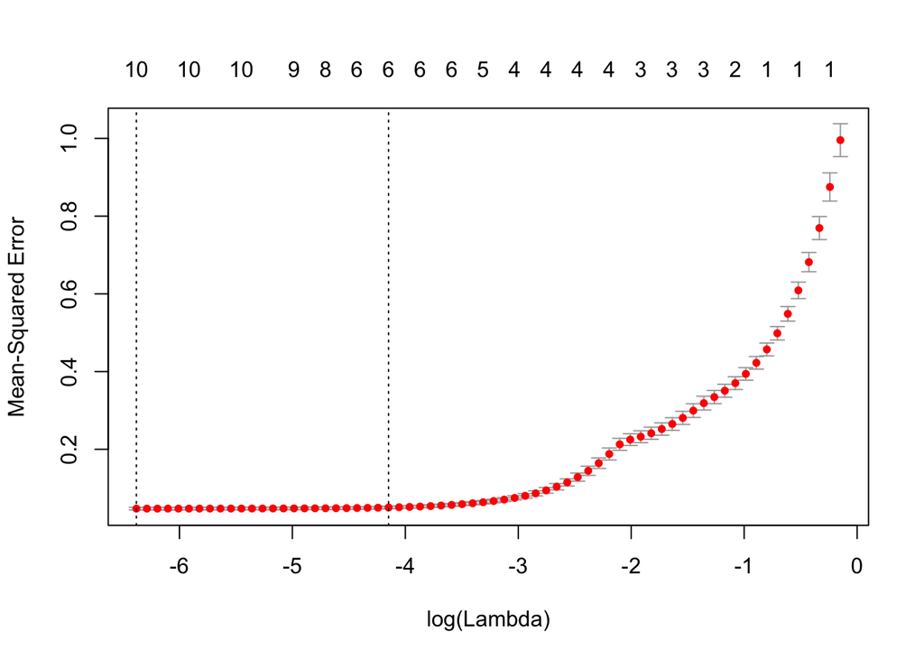

```r
plot(cv.credit.lasso, xvar = 'lambda')
```

```r
# Compare the models using RMS: OLS, GD,Ridge, Lasso
y_hat_ols <- predict(ols_credit, credit_balance)
RMSE_OLS <- sqrt(mean((credit$Balance-y_hat_ols)^2))
RMSE_OLS
```

```
## [1] 693.102
```

```r
y_hat_gd <- predit_GD_creditv1
RSME_gd <- sqrt(mean((gd_credit_test-y_hat_gd)^2))
RSME_gd
```

```
## [1] 1.118997
```

```r
y_hat_ridge <- predict(cv.credit.ridge, predit_test)
RMSE_Ridge <- sqrt(mean((target_test-y_hat_ridge)^2))
RMSE_Ridge
```

```
## [1] 0.2716562
```

```r
y_hat_lasso <- predict(cv.credit.lasso, predit_test)
RMSE_Lasso <- sqrt(mean((target_test-y_hat_lasso)^2))
RMSE_Lasso
```

```
## [1] 0.2162273
```

4. Assume your main interest is prediction rather than inference, given your results in (a)-(c) which model would you report and why?

The OLS is great to predit and also Ridge and Lasso are great too. We need to check over-fitting, RMSE and parameters then decide the model. This case Lasso model is best because RMSE is the lowest.

5. Between the ridge and lasso regression modeling, which is the best model and why? Remember to fix the seed in R before doing your cross validation.

The Lasso model is better than the Ridge model because of RMSE’s value